# GGPlot Homework

Author

Dez Waag

Published

October 8, 2026

Abstract

Data from iNaturalist documenting observations of the Spiranthes orchid genus across Virginia were analyzed to compare observation frequency among taxa, coordinate obscuration, and seasonal observation timing throughout the year.

## Introduction

### Lady’s Tresses Orchid, Genus *Spiranthes*

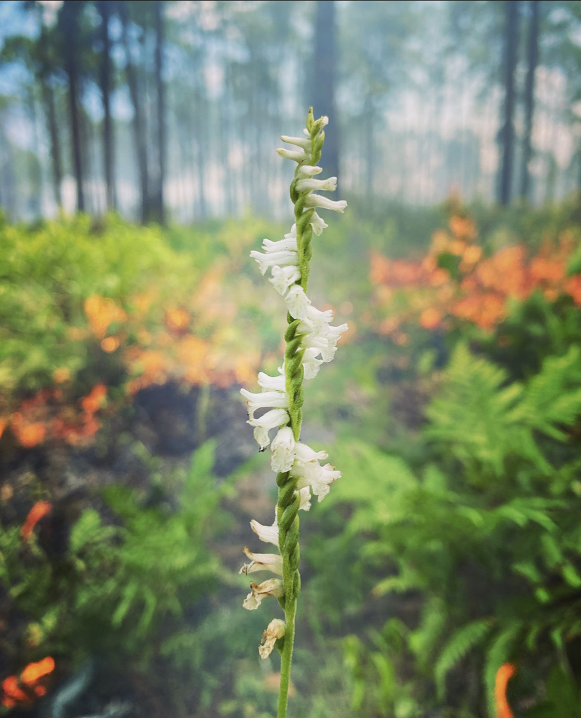

Spiranthes praecox, © Bryan Ames all rights reserved

**The observations I chose to examine are those of the Lady’s Tresses orchid, or the *Spiranthes* orchid.** This terrestrial orchid is native to the US and its members of the genus occur across much of the country, as shown below.

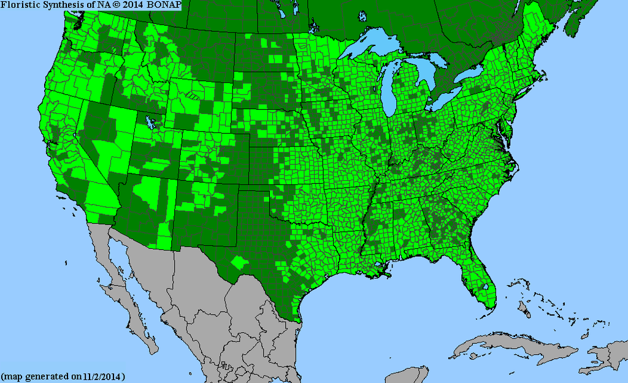

Spiranthes Range USA, BONAP

**Since *Spiranthes* is fairly common,** I decided to analyze its presence across Virginia using a publicly available dataset from iNaturalist. Since this orchid taxa doesn’t appear on the Virginia endangered species list, some location data may instead be hidden for privacy or sensitivity concerns, such as observations made on private property. Because of these reasons, I focused primarily on observation date, differences in observation frequency among taxa, and the occurrence of coordinate obscuration rather than attempting to interpret exact geographic locations.

## Methods

### iNaturalist Observations of *Spiranthes* in Virginia

This data set was gathered from iNaturalist, specifically gathering observations of orchids in the *Spiranthes* genus located in Virginia. Below is a summary of the workable data.

```r
library(tidyverse)
library(lubridate)
library(knitr)
library(kableExtra)
library(wesanderson)

url <- "https://docs.google.com/spreadsheets/d/e/2PACX-1vTZv5a7RrieA5SQjvth6zJhLpkYt71Hy_sMI3jSD5KydRViEL-iq5760IPkA-b87g/pub?gid=1866293273&single=true&output=csv"

spiranthes_raw <- read_csv( url )

spiranthes <- spiranthes_raw |>
  select(Species = scientific_name,
        Observed = observed_on,
        Latitude = latitude,
        Obscured = coordinates_obscured ) |>
  mutate( Observed = mdy(Observed),
        DayOfYear = yday(Observed) )

summary(spiranthes)
```

```
      Species       Observed             Latitude      Obscured
 Length   :976   Min.   :2007-09-02   Min.   :36.41   Mode :logical
 N.unique : 16   1st Qu.:2021-08-03   1st Qu.:37.01   FALSE:659
 N.blank  :  0   Median :2023-08-26   Median :37.68   TRUE :317
 Min.nchar: 17   Mean   :2023-03-04   Mean   :37.76
 Max.nchar: 29   3rd Qu.:2025-06-26   3rd Qu.:38.62
                 Max.   :2026-09-18   Max.   :39.24
   DayOfYear
 Min.   :  7.0
 1st Qu.:217.0
 Median :234.0
 Mean   :235.2
 3rd Qu.:267.0
 Max.   :341.0
```

**Defining The Dataset** — In the above run cell, raw data was taken from the .csv and defined. Below are the many columns that iNaturalist provides for data framing.

```r
names(spiranthes_raw)
```

```
 [1] "id"                            "observed_on_string"
 [3] "observed_on"                   "time_observed_at"
 [5] "user_id"                       "url"
 [7] "num_identification_agreements" "captive_cultivated"
 [9] "place_guess"                   "latitude"
[11] "longitude"                     "positional_accuracy"
[13] "private_place_guess"           "private_latitude"
[15] "private_longitude"             "public_positional_accuracy"
[17] "geoprivacy"                    "taxon_geoprivacy"
[19] "coordinates_obscured"          "positioning_method"
[21] "positioning_device"            "species_guess"
[23] "scientific_name"               "common_name"
[25] "iconic_taxon_name"             "taxon_id"
```

Since the dataset had many columns that were ultimately unusable, I defined terms and made the raw data into variables that are easier to engage with, listed below.

```r
names(spiranthes)
```

```
[1] "Species"   "Observed"  "Latitude"  "Obscured"  "DayOfYear"
```

With the data defined it is easier to analyze.

### Analysis

**Data Mutation** — After defining the data into a more workable fashion, we are able to summarize the observation count totals by month. The Observed variable was originally stored as text in month-day-year format, so I used `mutate()` with `mdy()` to convert it into a date and `yday()` to derive its numerical day of the year. I then grouped the observations by species, and summarized observation count, and day of year observed.

```r
spiranthes |>
  mutate( Month = month(Observed, label = TRUE) ) -> df
summary( df$Month )
```

```
Jan Feb Mar Apr May Jun Jul Aug Sep Oct Nov Dec
  2   1   1   0  20  97  87 386 186 183  12   1
```

As you can see, August has the highest number of observations at 386 total. Next we summarize the day of year average to see how it compares.

```r
summary( df$DayOfYear )
```

```
   Min. 1st Qu.  Median    Mean 3rd Qu.    Max.
    7.0   217.0   234.0   235.2   267.0   341.0
```

The mean observation day was day 235.2 of the year, corresponding to approximately August 23. This aligns with the monthly observation counts, which show that *Spiranthes* observations were most frequently recorded during August.

```r
mean_day <- mean(df$DayOfYear, na.rm = TRUE)
as.Date("2025-01-01") + round(mean_day) - 1
```

```
[1] "2025-08-23"
```

**Observations Throughout The Year** — Here we are able to take the previously mutated data display and present it in a graphed format for ease of interpretation.

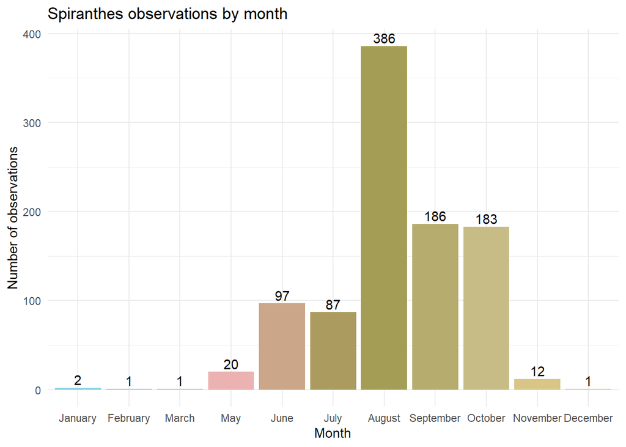

```r
monthly_counts <- spiranthes |>
  mutate( Month = month(Observed, label = TRUE, abbr = FALSE)) |>
  count(Month)

monthly_counts |>
  ggplot( aes( x = Month, y = n, fill = Month)) +
  geom_col() +
  geom_text( aes(label = n), vjust = -0.3 ) +
   scale_fill_manual(
    values = wes_palette( "Moonrise3", n = 12,
    type = "continuous" )) +
  labs( x = "Month", y = "Number of observations",
        title = "Spiranthes observations by month" ) +
        theme_minimal() + theme( legend.position = "none" )
```

Here we can see that August is visibly the month with the highest observations.

```r
species_counts <- spiranthes |>
  count(Species, Obscured)

species_counts_wide <- spiranthes |>
  count(Species, Obscured) |>
  pivot_wider(
    names_from = Obscured,
    values_from = n,
    values_fill = 0,
    names_prefix = "Obscured_" ) |>
  mutate( Total = Obscured_FALSE + Obscured_TRUE ) |>
  arrange(desc(Total))
kable(species_counts_wide)
```

| Species | Obscured_FALSE | Obscured_TRUE | Total |
| --- | --- | --- | --- |
| Spiranthes lacera gracilis | 160 | 41 | 201 |
| Spiranthes vernalis | 151 | 35 | 186 |
| Spiranthes lacera | 157 | 21 | 178 |
| Spiranthes ochroleuca | 0 | 82 | 82 |
| Spiranthes ovalis erostellata | 56 | 8 | 64 |
| Spiranthes ovalis | 42 | 14 | 56 |
| Spiranthes cernua | 39 | 11 | 50 |
| Spiranthes odorata | 0 | 43 | 43 |
| Spiranthes tuberosa | 22 | 20 | 42 |
| Spiranthes arcisepala | 27 | 7 | 34 |
| Spiranthes sylvatica | 0 | 16 | 16 |
| Spiranthes bightensis | 1 | 7 | 8 |
| Spiranthes praecox | 4 | 2 | 6 |
| Spiranthes lucida | 0 | 5 | 5 |
| Spiranthes magnicamporum | 0 | 4 | 4 |
| Spiranthes eatonii | 0 | 1 | 1 |

Since each species has been clearly named and their total observation counts calculated, we can now visualize the difference between obscured and non-obscured data points using a graph to further interpret the data.

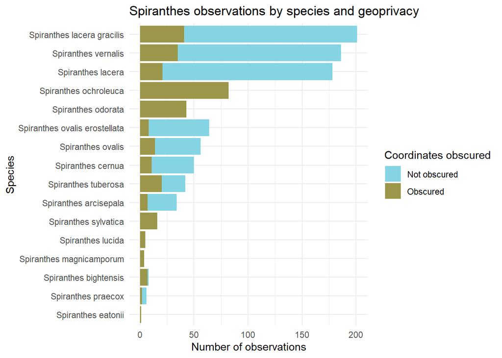

```r
species_counts |>
  ggplot( aes(x = reorder(Species, n),
        y = n,
        fill = Obscured  ) ) +
  geom_col(position = "stack") +
  coord_flip() +
  scale_fill_manual( values = wes_palette("Moonrise3")[c(1, 3)],
    labels = c( "FALSE" = "Not obscured", "TRUE" = "Obscured" ) ) +
  labs( x = "Species",
        y = "Number of observations",
        fill = "Coordinates obscured",
        title = "Spiranthes observations by species and geoprivacy" ) + theme_minimal()
```

**Summarized Table** – After viewing the limited dataset in a variety of ways, below I have compiled a table that displays minimum, mean, and maximum day of year, alongside the total observations.

```r
spiranthes |> select( Species, Observed, Obscured, DayOfYear ) |>
  mutate( Month = month(Observed, label = TRUE, abbr = FALSE) ) |>
  filter( !is.na(Species), !is.na(DayOfYear)) |>
  group_by(Species) |>
  summarize( Sightings = n(), `Day Min` = min(DayOfYear),
            `Day Mean` = mean(DayOfYear), `Day Max` = max(DayOfYear)) |>
  arrange(desc(Sightings)) -> species_summary
  kable(species_summary)
```

| Species | Sightings | Day Min | Day Mean | Day Max |
| --- | --- | --- | --- | --- |
| Spiranthes lacera gracilis | 201 | 71 | 229.1144 | 341 |
| Spiranthes vernalis | 186 | 156 | 190.2312 | 284 |
| Spiranthes lacera | 178 | 198 | 227.3596 | 263 |
| Spiranthes ochroleuca | 82 | 240 | 275.5244 | 305 |
| Spiranthes ovalis erostellata | 64 | 245 | 267.7188 | 309 |
| Spiranthes ovalis | 56 | 37 | 266.3214 | 304 |
| Spiranthes cernua | 50 | 7 | 278.0600 | 324 |
| Spiranthes odorata | 43 | 272 | 290.3488 | 318 |
| Spiranthes tuberosa | 42 | 209 | 237.1905 | 269 |
| Spiranthes arcisepala | 34 | 250 | 271.7647 | 306 |
| Spiranthes sylvatica | 16 | 149 | 149.0000 | 149 |
| Spiranthes bightensis | 8 | 277 | 284.7500 | 291 |
| Spiranthes praecox | 6 | 152 | 159.8333 | 169 |
| Spiranthes lucida | 5 | 127 | 140.6000 | 167 |
| Spiranthes magnicamporum | 4 | 260 | 276.5000 | 292 |
| Spiranthes eatonii | 1 | 7 | 7.0000 | 7 |

## Results

The dataset contained 976 *Spiranthes* observations representing 16 taxa across Virginia. Observations showed a strong seasonal pattern, with 386 records occurring in August, or approximately 40% of all observations. The mean observation occurred on day 235.2 of the year, corresponding to approximately August 23, further demonstrating that observations were concentrated in late summer. Very few records occurred during winter and early spring, while observation frequency increased substantially beginning in May and remained relatively high through October.

Observation frequency also varied considerably among taxa. *Spiranthes lacera gracilis* was the most frequently recorded taxon with 201 observations, followed by *Spiranthes vernalis* with 186 and *Spiranthes lacera* with 178. Together, these three taxa accounted for more than half of all observations in the dataset, while several other taxa were represented by only a small number of records.

Coordinate obscuration provided an additional difference among the observations. Of the 976 records, 317 had obscured coordinates and 659 did not, meaning that approximately one-third of the observations had locations that could not be interpreted as exact collection points. The proportion of obscured records also differed among taxa. Taken together, the monthly, taxonomic, and geoprivacy summaries demonstrate that the iNaturalist dataset can reveal clear patterns in when *Spiranthes* orchids are observed, which taxa are most frequently documented, and how much of the available spatial information is obscured.

### Questions

1. Five of the six manipulation verbs hand back a data frame with the same rows they were given; one does not. Which one, and what does it return instead?

– `summarize()` is the manipulation verb that reduces the original rows into summary values. When used with `group_by()`, it returns one summarized row for each group instead of preserving every individual observation.

2. Your table has one row per group because of `group_by()`. What would the same `summarize()` call produce if you deleted the `group_by()` line, and why?

– Without `group_by(Species)`, `summarize()` would return a single row summarizing the entire dataset. The minimum, mean, and maximum values would be calculated across all observations together rather than separately for each species.

# GGPlot Section

## Plot 1 — When during the year are Spiranthes observed?

*Spiranthes* observations are concentrated later in the year, with the distribution showing the greatest number of observations during the late-summer period.

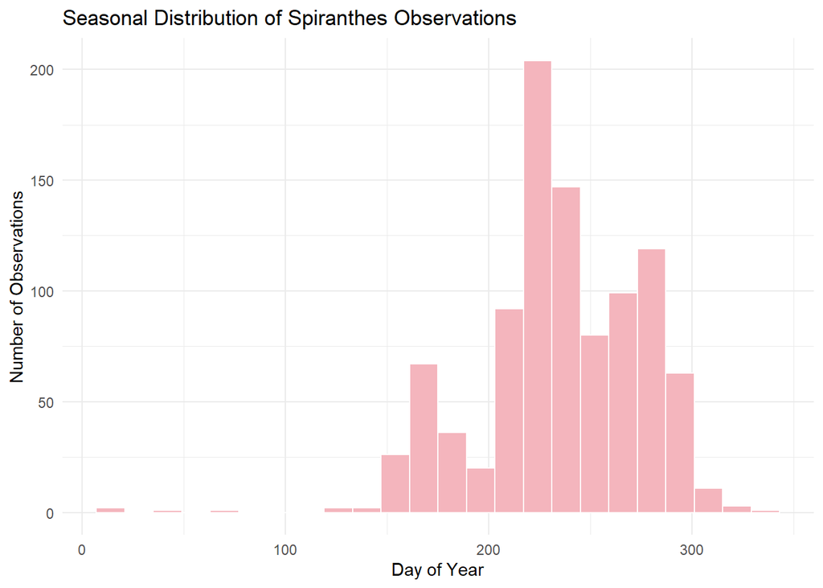

```r
 ggplot(spiranthes, aes(x = DayOfYear)) +
  geom_histogram(
    binwidth = 14,
    fill = wes_palette("Moonrise3")[2],
    color = "white"
  ) +
  labs(
    x = "Day of Year",
    y = "Number of Observations",
    title = "Seasonal Distribution of Spiranthes Observations"
  ) +
  theme_minimal()
```

## Plot 2 — Where are observations geographically?

Unobscured *Spiranthes* observations are distributed across Virginia, showing the geographic spread of recorded locations throughout the state.

```r
spiranthes <- spiranthes_raw |> select(
    Species = scientific_name,
    Observed = observed_on,
    Latitude = latitude,
    Longitude = longitude,
    Obscured = coordinates_obscured ) |>
  mutate(
    Observed = mdy(Observed),
    DayOfYear = yday(Observed) )

spatial_data <- spiranthes |> filter(
    Obscured == FALSE,
    !is.na(Latitude),
    !is.na(Longitude) )
```

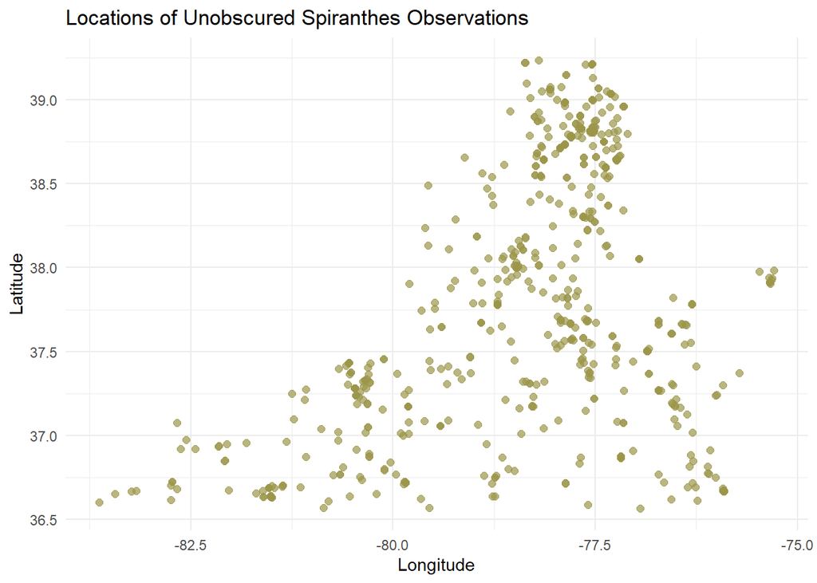

```r
ggplot( spatial_data, aes(x = Longitude, y = Latitude) ) +
  geom_point( color = wes_palette("Moonrise3")[3],
              alpha = 0.7, size = 2 ) +
  labs( x = "Longitude", y = "Latitude",
        title = "Locations of Unobscured Spiranthes Observations" ) +
  theme_minimal()
```

## Plot 3 — Do different taxa appear in different areas?

Coloring observations by taxon shows that different *Spiranthes* taxa occur across overlapping but somewhat varied geographic areas within Virginia.

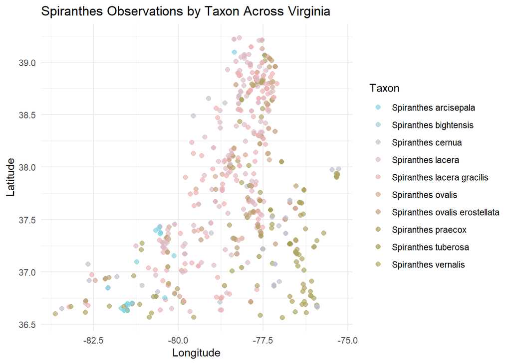

```r
 ggplot( spatial_data,
  aes( x = Longitude, y = Latitude, color = Species ) ) +
  geom_point( alpha = 0.7, size = 2 ) +
  labs( x = "Longitude", y = "Latitude", color = "Taxon",
    title = "Spiranthes Observations by Taxon Across Virginia" ) +

scale_color_manual(
  values = wes_palette( "Moonrise3", n = 16, type = "continuous" ) ) +
  theme_minimal()
```

## Plot 4 — Can we communicate the seasonal pattern more directly?

Monthly observation totals show that August had the highest number of *Spiranthes* observations, clearly emphasizing the late-summer peak in activity.

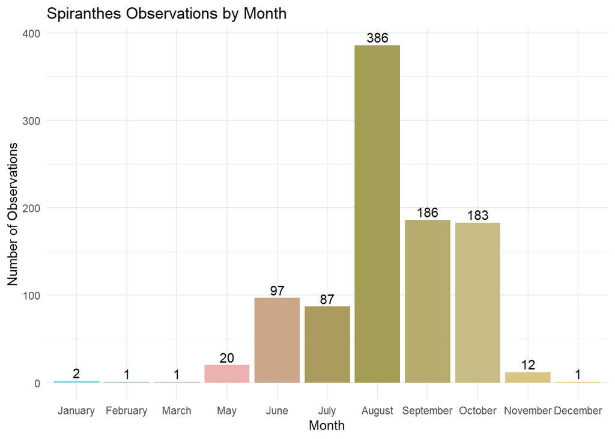

```r
 monthly_counts |>
  ggplot( aes( x = Month, y = n, fill = Month )) +
  geom_col() + geom_text( aes(label = n), vjust = -0.3 ) +
  scale_fill_manual( values = wes_palette( "Moonrise3", n = 12, type = "continuous" )) +
  labs( x = "Month", y = "Number of Observations",
        title = "Spiranthes Observations by Month" ) +
  theme_minimal() + theme( legend.position = "none" )
```